# ANSPoints User Manual

If you are an American Nuclear Society member at Texas A&M University you are at the right place!

This document will guide you through using the ANS Points application so you can earn points while participating in all the great events that ANS provides every semester.

## Attending an ANS event? Get your points!

### **QR Code**

Scan the QR code that an ANS officer will display at the meeting.

[figure not shown]

*Sample QR code display for an ANS event*

Enter your `TAMU email`, `first name`, and `last name`, and click `Check In`. You're done!

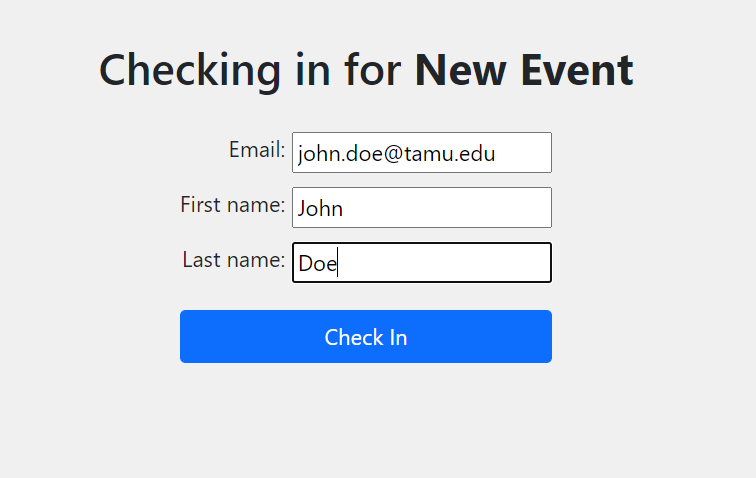

*Enter your information to check in for “New Event”*

[figure not shown]

### **Event Code**

If a QR code is not being displayed at the meeting, or you are attending the meeting remotely, don’t worry, if you are given the `event code`, you can enter it instead! Navigate to the *events page* (the homepage), find the ongoing event you are attending, click join, and enter the `event code`.

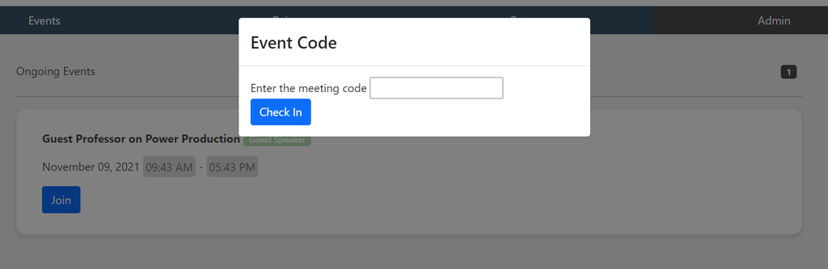

*Event code pop-up after clicking `Join` on “Guest Professors on Power Production”*

Enter your `TAMU email`, `first name`, and `last name` (same form as above from the QR code). You're done!

## Looking for an upcoming ANS event?

Navigate to the *events page* and scroll to `Upcoming Events`. Here you can see what events you can attend to get points in the future!

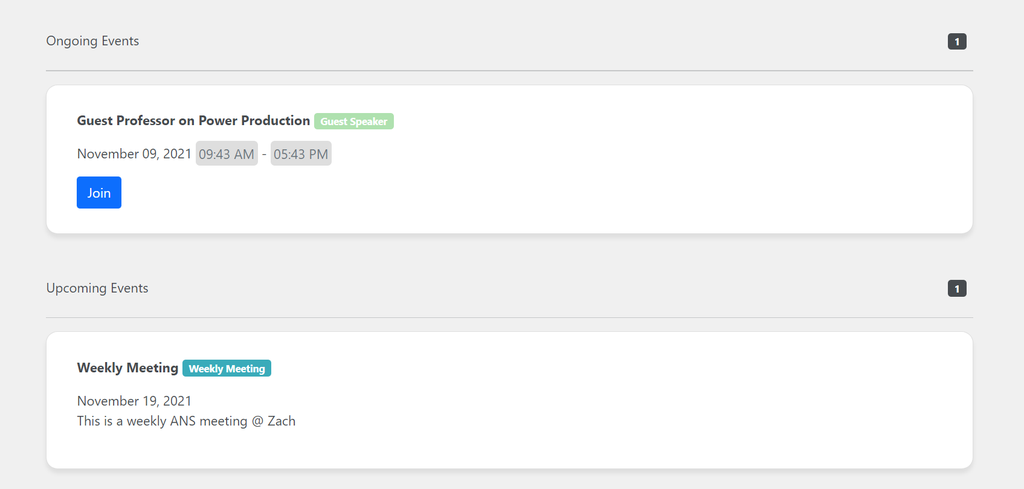

*View upcoming events such as “Weekly Meeting”*

## Want to check how many points you have?

Navigate to the *points page*. Enter your `TAMU email` in the search bar and click `Search`. This will show your email (if you have previously signed in to an event) and the number of points you currently have! You can also search your friends' emails and if they have fewer points, tell them to pick up the slack!

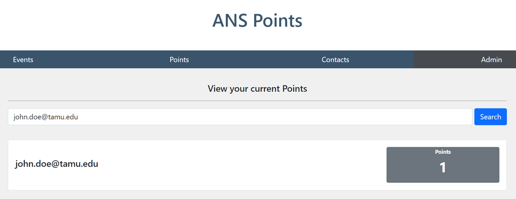

*John Doe viewing his points after signing into “Guest Professors on Power Production”*

## Want to contact an ANS officer or an event speaker?

Navigate to the *contacts page*. The contact cards shown are the information of the officers, speakers, or others that ANS officers have provided you to contact.

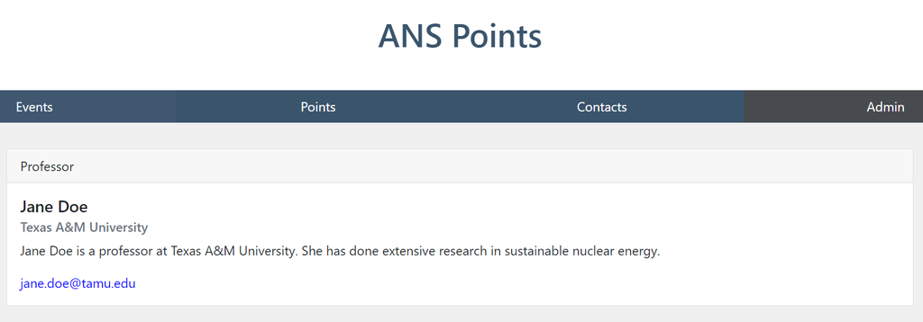

*Example professor contact card*

## Missing points?

If you are missing point(s) that you believe you should have received, contact an ANS officer at americannuclearsociety.tamu@gmail.com or https://ans-tamu.weebly.com/contact.html and they can manually enter your point(s) if your request is validated.